# Prediction

### Loading the required libraries

```r
library(ggplot2)
library(dplyr)
library(Hmisc)
library(psych)
library(tidyr)
```

### Reading the dataset

```r
movie <- read.csv('../Preprocessing/movie_clean.csv', stringsAsFactors = F)
str(movie)
```

```
## 'data.frame':    5022 obs. of  54 variables:
##  $ X                        : int  1 2 3 4 5 6 7 8 9 10 ...
##  $ color                    : chr  "Color" "Color" "Color" "Color" ...
##  $ director_name            : chr  "James Cameron" "Gore Verbinski" "Sam Mendes" "Christopher Nolan" ...
##  $ num_critic_for_reviews   : num  723 302 602 813 462 392 324 635 375 673 ...
##  $ duration                 : num  178 169 148 164 132 156 100 141 153 183 ...
##  $ director_facebook_likes  : num  0 563 0 22000 475 0 15 0 282 0 ...
##  $ actor_3_facebook_likes   : num  855 1000 161 23000 530 4000 284 19000 10000 2000 ...
##  $ actor_2_name             : chr  "Joel David Moore" "Orlando Bloom" "Rory Kinnear" "Christian Bale" ...
##  $ actor_1_facebook_likes   : num  1000 40000 11000 27000 640 24000 799 26000 25000 15000 ...
##  $ gross                    : num  7.61e+08 3.09e+08 2.00e+08 4.48e+08 7.31e+07 ...
##  $ actor_1_name             : chr  "CCH Pounder" "Johnny Depp" "Christoph Waltz" "Tom Hardy" ...
##  $ movie_title              : chr  "AvatarÂ " "Pirates of the Caribbean: At World's EndÂ " "SpectreÂ " "The Dark Knight RisesÂ " ...
##  $ num_voted_users          : int  886204 471220 275868 1144337 212204 383056 294810 462669 321795 371639 ...
##  $ cast_total_facebook_likes: int  4834 48350 11700 106759 1873 46055 2036 92000 58753 24450 ...
```

[output cut: 40 more lines]

### Multiple Linear Regression - Variable Selection

```r
movie_sub <- subset(movie, select = c(3, 4, 5, 8, 9, 13, 15, 22, 27, 28:53, 25, 26))
```

### Construct the model

```r
set.seed(123)
train_size <- 0.8
train_index <- sample.int(length(movie$imdb_score), length(movie$imdb_score) * train_size)
train_sample <- movie[train_index,]
test_sample <- movie[-train_index,]
```

### Fit the model

```r
fit <- lm(imdb_score ~ num_critic_for_reviews + duration +    director_facebook_likes + actor_1_facebook_likes + gross + cast_total_facebook_likes + facenumber_in_poster + budget + movie_facebook_likes + Action + Adventure + Fantasy +  Thriller + Documentary + Romance + Animation + Comedy + Family + Musical +  Mystery + Western + Drama + History + Sport + Crime + Horror + War + Biography + Music + News + Short, data=train_sample)
summary(fit)
```

```
##
## Call:
## lm(formula = imdb_score ~ num_critic_for_reviews + duration +
##     director_facebook_likes + actor_1_facebook_likes + gross +
##     cast_total_facebook_likes + facenumber_in_poster + budget +
##     movie_facebook_likes + Action + Adventure + Fantasy + Thriller +
##     Documentary + Romance + Animation + Comedy + Family + Musical +
##     Mystery + Western + Drama + History + Sport + Crime + Horror +
##     War + Biography + Music + News + Short, data = train_sample)
##
## Residuals:
##     Min      1Q  Median      3Q     Max
## -5.5361 -0.4912  0.0770  0.5949  3.4765
##
## Coefficients:
##                             Estimate Std. Error t value Pr(>|t|)
## (Intercept)                5.475e+00  8.577e-02  63.836  < 2e-16 ***
## num_critic_for_reviews     2.361e-03  1.836e-04  12.860  < 2e-16 ***
## duration                   4.457e-03  7.051e-04   6.321 2.88e-10 ***
## director_facebook_likes    3.107e-05  5.618e-06   5.530 3.41e-08 ***
## actor_1_facebook_likes     1.406e-05  3.385e-06   4.155 3.32e-05 ***
## gross                      1.978e-09  3.019e-10   6.551 6.45e-11 ***
## cast_total_facebook_likes -1.153e-05  2.908e-06  -3.964 7.51e-05 ***
## facenumber_in_poster      -1.954e-02  7.539e-03  -2.592  0.00958 **
## budget                    -3.100e-10  1.615e-10  -1.920  0.05498 .
## movie_facebook_likes       6.805e-07  1.074e-06   0.634  0.52622
## Action                    -2.542e-01  4.323e-02  -5.880 4.44e-09 ***
## Adventure                 -1.365e-02  4.780e-02  -0.286  0.77525
## Fantasy                   -1.838e-02  5.096e-02  -0.361  0.71838
## Thriller                  -2.649e-01  4.234e-02  -6.255 4.41e-10 ***
## Documentary                9.640e-01  1.085e-01   8.883  < 2e-16 ***
## Romance                   -6.036e-02  3.910e-02  -1.544  0.12277
## Animation                  5.386e-01  8.600e-02   6.263 4.18e-10 ***
## Comedy                    -1.801e-01  3.911e-02  -4.605 4.25e-06 ***
## Family                    -2.655e-01  6.285e-02  -4.224 2.45e-05 ***
## Musical                    1.489e-01  9.575e-02   1.555  0.11999
## Mystery                    9.471e-02  5.408e-02   1.751  0.07999 .
## Western                    1.199e-01  1.138e-01   1.054  0.29182
## Drama                      5.372e-01  3.800e-02  14.138  < 2e-16 ***
## History                    7.109e-02  8.583e-02   0.828  0.40761
## Sport                     -2.935e-02  8.458e-02  -0.347  0.72863
## Crime                      2.082e-01  4.417e-02   4.713 2.52e-06 ***
## Horror                    -4.226e-01  5.622e-02  -7.517 6.91e-14 ***
## War                        2.105e-01  8.071e-02   2.608  0.00915 **
## Biography                  1.580e-01  6.935e-02   2.278  0.02275 *
## Music                     -1.834e-01  7.321e-02  -2.506  0.01226 *
## News                       6.952e-02  5.559e-01   0.125  0.90048
## Short                      8.437e-01  6.742e-01   1.251  0.21085
## ---
## Signif. codes:  0 '***' 0.001 '**' 0.01 '*' 0.05 '.' 0.1 ' ' 1
##
## Residual standard error: 0.9452 on 3985 degrees of freedom
## Multiple R-squared:    0.3,  Adjusted R-squared:  0.2946
## F-statistic: 55.09 on 31 and 3985 DF,  p-value: < 2.2e-16
```

Model with all the variables

```r
fit <- lm(imdb_score ~ num_critic_for_reviews + duration +  director_facebook_likes + actor_1_facebook_likes +  cast_total_facebook_likes + facenumber_in_poster + Action + Thriller + Documentary + Animation + Comedy + Family + Mystery + Drama + Crime + Horror + War + Biography + Music, data=train_sample)
summary(fit)
```

```
##
## Call:
## lm(formula = imdb_score ~ num_critic_for_reviews + duration +
##     director_facebook_likes + actor_1_facebook_likes + cast_total_facebook_likes +
##     facenumber_in_poster + Action + Thriller + Documentary +
##     Animation + Comedy + Family + Mystery + Drama + Crime + Horror +
##     War + Biography + Music, data = train_sample)
##
## Residuals:
##     Min      1Q  Median      3Q     Max
## -5.4419 -0.5039  0.0730  0.6058  3.5303
##
## Coefficients:
##                             Estimate Std. Error t value Pr(>|t|)
## (Intercept)                5.437e+00  8.449e-02  64.356  < 2e-16 ***
## num_critic_for_reviews     2.715e-03  1.376e-04  19.737  < 2e-16 ***
## duration                   5.114e-03  6.851e-04   7.465 1.02e-13 ***
## director_facebook_likes    3.394e-05  5.623e-06   6.035 1.73e-09 ***
## actor_1_facebook_likes     1.021e-05  3.338e-06   3.058 0.002241 **
## cast_total_facebook_likes -7.837e-06  2.855e-06  -2.745 0.006073 **
## facenumber_in_poster      -2.136e-02  7.554e-03  -2.827 0.004719 **
## Action                    -2.264e-01  4.125e-02  -5.487 4.33e-08 ***
## Thriller                  -2.721e-01  4.201e-02  -6.479 1.04e-10 ***
## Documentary                9.796e-01  1.063e-01   9.219  < 2e-16 ***
## Animation                  5.819e-01  8.465e-02   6.874 7.22e-12 ***
## Comedy                    -1.896e-01  3.866e-02  -4.906 9.69e-07 ***
## Family                    -2.086e-01  5.951e-02  -3.505 0.000461 ***
## Mystery                    9.483e-02  5.424e-02   1.748 0.080490 .
## Drama                      5.019e-01  3.705e-02  13.548  < 2e-16 ***
## Crime                      1.978e-01  4.321e-02   4.577 4.87e-06 ***
## Horror                    -4.380e-01  5.508e-02  -7.953 2.35e-15 ***
## War                        2.107e-01  7.733e-02   2.724 0.006470 **
## Biography                  1.570e-01  6.709e-02   2.340 0.019345 *
## Music                     -1.771e-01  7.298e-02  -2.427 0.015268 *
## ---
## Signif. codes:  0 '***' 0.001 '**' 0.01 '*' 0.05 '.' 0.1 ' ' 1
##
## Residual standard error: 0.9501 on 3997 degrees of freedom
## Multiple R-squared:  0.2905, Adjusted R-squared:  0.2871
## F-statistic: 86.14 on 19 and 3997 DF,  p-value: < 2.2e-16
```

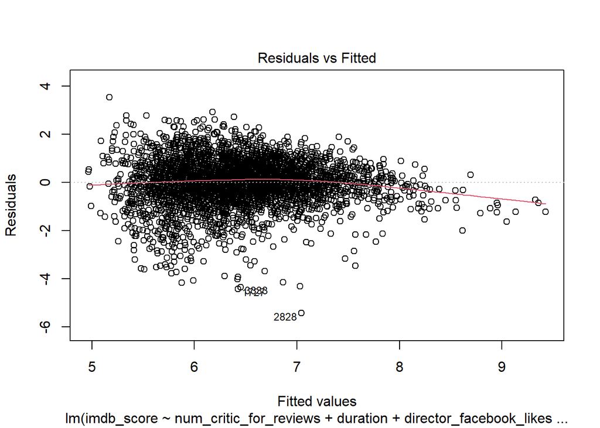

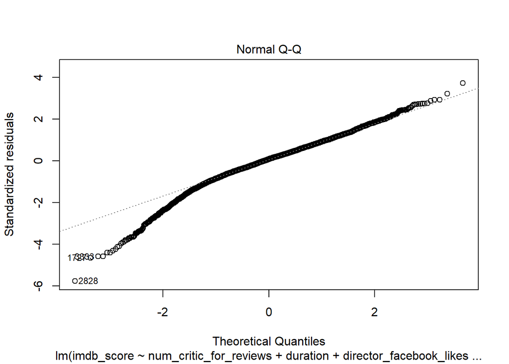

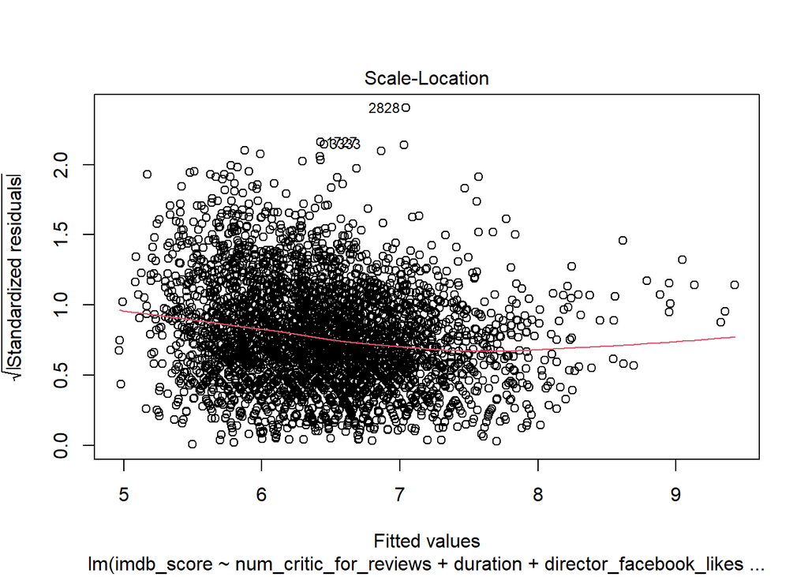

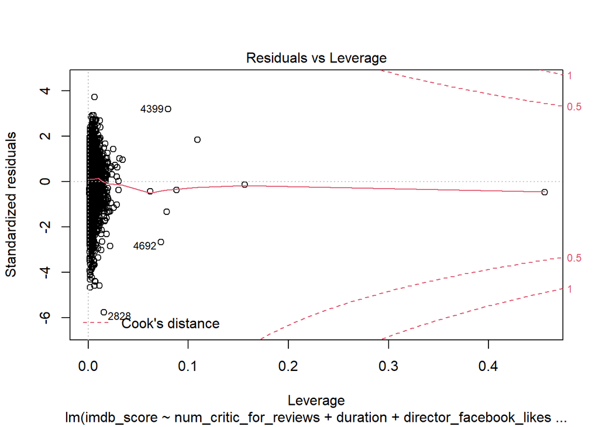

```r
plot(fit)
```

From the residuals vs fitted graph we can see that there are quite a few outliers at the end and overall the dispersion is uneven. From the Normal Q-Q plot we can see that there is a huge deviation at the start.

```r
train_sample$pred_score <- predict(fit, newdata = subset(train_sample, select=c(imdb_score, num_critic_for_reviews, duration, director_facebook_likes, actor_1_facebook_likes, cast_total_facebook_likes, facenumber_in_poster, movie_facebook_likes, Action ,Adventure, Fantasy,Thriller, Documentary ,Romance ,Animation ,Comedy ,Family ,Musical ,Mystery, Western ,Drama ,History ,Sport ,Crime ,Horror,War ,Biography ,Music, News ,Short)))
test_sample$pred_score <- predict(fit, newdata = subset(test_sample, select=c(imdb_score, num_critic_for_reviews, duration, director_facebook_likes, actor_1_facebook_likes, cast_total_facebook_likes, facenumber_in_poster, movie_facebook_likes, Action ,Adventure, Fantasy,Thriller, Documentary ,Romance ,Animation ,Comedy ,Family ,Musical ,Mystery, Western ,Drama ,History ,Sport ,Crime ,Horror,War ,Biography ,Music, News ,Short)))
```

### Evaluating on train set

```r
train_corr <- round(cor(train_sample$pred_score, train_sample$imdb_score), 2)
train_rmse <- round(sqrt(mean((train_sample$pred_score - train_sample$imdb_score)^2)), 2)
train_mae <- round(mean(abs(train_sample$pred_score - train_sample$imdb_score)), 2)
c(train_corr^2, train_rmse, train_mae)
```

```
## [1] 0.2916 0.9500 0.7100
```

The predicted and the actual scores are not highly correlated. RMSE value is high which means the model doesn’t fit the data well MAE is also high which is bad as the predicted imdb score values lie in 0-10 range

### Evaluating on test set

```r
test_rmse <- round(sqrt(mean((test_sample$pred_score - test_sample$imdb_score)^2)), 2)
test_mae <- round(mean(abs(test_sample$pred_score - test_sample$imdb_score)), 2)
c(test_rmse, test_mae)
```

```
## [1] 0.94 0.71
```

Test set also has high RMSE and MAE values

### Decision Tree

```r
library(rpart)
library(rpart.plot)
movie_sub_dectre <- movie
movie_sub_dectre$imdb_cat <- as.numeric(cut2(movie_sub$imdb_score, g=3))

movie_sub_dectre$imdb_cat <- factor(x=movie_sub_dectre$imdb_cat, levels=sort(unique(movie_sub_dectre$imdb_cat)), labels = c("Low", "Medium", "High"))
```

Distributing the scores into 3 different categories Low, Medium and High

```r
set.seed(123)
train_size <- 0.8
train_index <- sample.int(length(movie_sub_dectre$imdb_cat), length(movie_sub_dectre$imdb_cat) * train_size)
train_sample <- movie_sub_dectre[train_index,]
test_sample <- movie_sub_dectre[-train_index,]
```

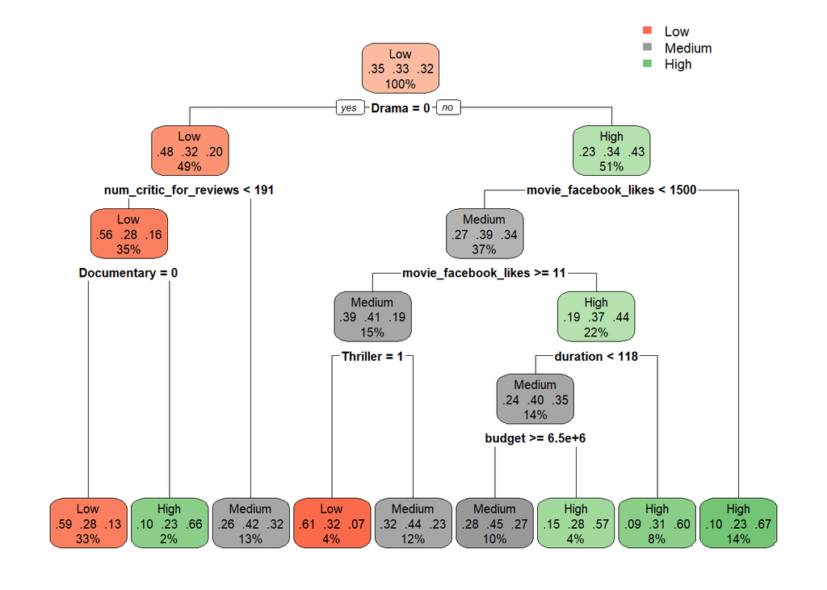

```r
fit <- rpart(imdb_cat ~ num_critic_for_reviews + duration + budget + director_facebook_likes + actor_1_facebook_likes + cast_total_facebook_likes + facenumber_in_poster + movie_facebook_likes + Action + Adventure + Fantasy +  Thriller + Documentary + Romance + Animation + Comedy + Family + Musical +  Mystery + Western + Drama + History + Sport + Crime + Horror + War + Biography + Music + News + Short, data=train_sample, method = 'class')
rpart.plot(fit)
```

```r
predicted <- predict(fit, test_sample, type = 'class')
table_mat <- table(test_sample$imdb_cat, predicted)
table_mat
```

```
##         predicted
##          Low Medium High
##   Low    216     97   45
##   Medium 113    161   78
##   High    39     92  164
```

```r
accuracy_Test <- sum(diag(table_mat)) / sum(table_mat)
print(paste('Accuracy for test', accuracy_Test))
```

```
## [1] "Accuracy for test 0.538308457711443"
```

Accuracy of 54% was achieved on the test data using the decision tree classifier

## Naive bayees using geners only

```r
library(e1071)
genre_sub <- subset(movie_sub_dectre, select = c(29:55))

index <- sample(1 : nrow(genre_sub), round(0.75 * nrow(genre_sub)))

train_cl <- genre_sub[index, ]
test_cl <- genre_sub[-index, ]

set.seed(120)

classifier_cl <- naiveBayes(imdb_cat ~ ., data = train_cl)
classifier_cl
```

```
##
## Naive Bayes Classifier for Discrete Predictors
##
## Call:
## naiveBayes.default(x = X, y = Y, laplace = laplace)
##
## A-priori probabilities:
## Y
##       Low    Medium      High
## 0.3467870 0.3380244 0.3151885
##
## Conditional probabilities:
##         Action
## Y             [,1]      [,2]
##   Low    0.2993874 0.4581652
##   Medium 0.2380204 0.4260391
##   High   0.1600674 0.3668231
##
##         Adventure
## Y             [,1]      [,2]
##   Low    0.2021440 0.4017529
##   Medium 0.1696779 0.3754971
##   High   0.1794440 0.3838854
##
##         Fantasy
## Y             [,1]      [,2]
##   Low    0.1493109 0.3565312
##   Medium 0.1194030 0.3243895
##   High   0.1002527 0.3004633
##
##         SciFi
## Y              [,1]      [,2]
##   Low    0.15696784 0.3639098
##   Medium 0.11783189 0.3225357
##   High   0.09351306 0.2912728
##
##         Thriller
## Y             [,1]      [,2]
##   Low    0.3147014 0.4645747
##   Medium 0.3079340 0.4618205
```

[output cut: 112 more lines]

```
##   Low    0.00000000 0.00000000
##   Medium 0.00000000 0.00000000
##   High   0.00084246 0.02902516
##
##         Short
## Y               [,1]       [,2]
##   Low    0.000000000 0.00000000
##   Medium 0.001571092 0.03962142
##   High   0.000842460 0.02902516
##
##         FilmNoir
## Y              [,1]       [,2]
##   Low    0.00000000 0.00000000
##   Medium 0.00000000 0.00000000
##   High   0.00252738 0.05023065
```

```r
y_pred <- predict(classifier_cl, newdata = test_cl)

cm <- table(test_cl$imdb_cat, y_pred)
cm
```

```
##         y_pred
##          Low Medium High
##   Low    181    261   11
##   Medium 103    291   14
##   High    86    265   44
```

```r
print(paste("Accuracy", sum(diag(cm)) / sum(cm)))
```

```
## [1] "Accuracy 0.410828025477707"
```

Accuracy of 41% was achieved with Naive bayees classifier

### KNN

```r
library(caTools)
library(class)
```

```r
set.seed(123)
train_size <- 0.8
train_index <- sample.int(length(movie_sub_dectre$imdb_cat), length(movie_sub_dectre$imdb_cat) * train_size)
train_sample <- movie_sub_dectre[train_index,]
test_sample <- movie_sub_dectre[-train_index,]

train_sample <- na.omit(train_sample)
test_sample <- na.omit(test_sample)

train_cl <- subset(train_sample, select = c(29:54))
test_cl <- subset(test_sample, select = c(29:54))

classifier_knn <- knn(train = train_cl,
                      test = test_cl,
                      cl = train_sample$imdb_cat,
                      k =100)
cm <- table(test_sample$imdb_cat, classifier_knn)
cm
```

```
##         classifier_knn
##          Low Medium High
##   Low    236     59   63
##   Medium 138     86  128
##   High    92     38  165
```

```r
misClassError <- mean(classifier_knn != test_sample$imdb_cat)
print(paste('Accuracy =', 1-misClassError))
```

```
## [1] "Accuracy = 0.484577114427861"
```

## Neural networks

```r
library(neuralnet)
movie_sub_dectre$imdb_num <- factor(x=movie_sub_dectre$imdb_cat, levels=sort(unique(movie_sub_dectre$imdb_cat)), labels = c(1,2,3))
#movie_sub_dectre$imdb_num = as.numeric(movie_sub_dectre$imdb_num)

#movie_idk = select(movie_sub_dectre, -c("imdb_cat"))
movie_idk <- subset(movie_sub_dectre, select=c(4,5,6,9,14,16,26,28, 55))
movie_idk$imdb_num <- factor(x=movie_idk$imdb_cat, levels=sort(unique(movie_idk$imdb_cat)), labels = c(1,2,3))
movie_idk$imdb_num = as.numeric(movie_idk$imdb_num)
movie_idk <- select(movie_idk, -c("imdb_cat"))
```

```r
index <- sample(1 : nrow(movie_idk),
                round(0.75 * nrow(movie_idk)))
maxs <- apply(movie_idk, 2, max)
mins <- apply(movie_idk, 2, min)
scaled <- as.data.frame(scale(movie_idk,
                              center = mins,
                              scale = maxs - mins))
aa = movie_idk[index, ]
ab = movie_idk[-index, ]

train_ <- scaled[index, ]
test_ <- scaled[-index, ]

train_$imdb_num = as.numeric(as.factor(aa$imdb_num))
test_$imdb_num = as.numeric(as.factor(ab$imdb_num))
```

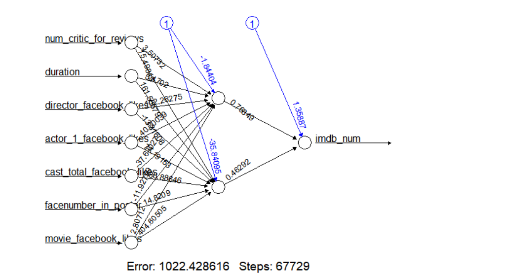

```r
NN = neuralnet(imdb_num ~ num_critic_for_reviews + duration + director_facebook_likes + actor_1_facebook_likes + cast_total_facebook_likes + facenumber_in_poster + movie_facebook_likes, data=train_, hidden = 2)
plot(NN)
```